# YouTube Engagement - Modeling Summary

LV

2025-08-12

## Load Libraries

```r
LoadLibraries <- function() {
  require(tidyverse)
  require(readxl)
  require(kableExtra)
}

LoadLibraries()
```

**RStudio: Checkpoint 1**

# Data Preprocessing

We moved to RStudio, as Orange3 does not provide the functionality needed for EDA or for creating variables like age_days and duration_bucket. We note this as a limitation when working with Orange3.

```r
df <- read_excel("Data/rossman_variables_raw.xlsx")
```

```
##  [1] "video_id"           "title"              "channel_id"
##  [4] "channel_title"      "published_at"       "description"
##  [7] "tags"               "category_id"        "default_lang"
## [10] "default_audio_lang" "duration_iso"       "duration_hms"
## [13] "dimension"          "definition"         "caption"
## [16] "licensed_content"   "projection"         "view_count"
## [19] "like_count"         "comment_count"      "favorite_count"
## [22] "privacy_status"     "upload_status"      "license"
## [25] "made_for_kids"      "recording_date"     "location_desc"
## [28] "location_lat"       "location_lng"       "was_livestream"
## [31] "actual_start"       "actual_end"         "viewers_peak"
## [34] "topic_categories"
```

## Data Preparation: Variable Creation & Removal

```r
df <- df %>% # Remove variables with near constant features
  dplyr::select(
    -topic_categories, -viewers_peak,
    -actual_end, -actual_start,
    -location_lng, -location_lat,
    -location_desc, -recording_date,
    -made_for_kids, -license,
    -privacy_status, -favorite_count,
    -dimension, -duration_iso,
    -default_audio_lang, -default_lang,
    -tags, -description,
    -channel_title, -channel_id,
    -title, -video_id
  ) %>% # Duration
  mutate(
    duration_seconds = as.numeric((lubridate::hms(duration_hms))),
    duration_bucket = cut(
      duration_seconds,
      breaks = c(-Inf, 480, 1200, Inf),
      labels = c("<8m", "8-20m", ">20m"),
      right = T
    )
  ) %>% # Time
  mutate(
    published_at = ymd_hms(published_at, tz = "UTC"),
    age_days = as.numeric(difftime(Sys.time(), published_at, units = "days")),
    weekday = wday(published_at, label = T, week_start = 1),
    weekend = as.integer(weekday %in% c("Sat", "Sun")),
    hour = hour(published_at),
    month = month(published_at, label = T)
  ) %>% # Age
  mutate(
    age_bin = cut(
      age_days,
      breaks = c(-Inf, 6, 30, 90, 180, 365, 730, 1095, Inf),
      labels = c("0–6d", "1–4w", "1–3m", "3–6m", "6–12m", "1–2y", "2–3y", "3y+"),
      right = TRUE
    )
  ) %>% # Convert to factors
  mutate(
    category_id = factor(category_id),
    hour = factor(hour)
  ) %>% # Remove leftovers
  dplyr::select(-duration_hms, -published_at)
```

```
## Number of rows after filtering: 3862
```

```
## Column names:
```

```
##  [1] "category_id"      "definition"       "caption"          "licensed_content"
##  [5] "projection"       "view_count"       "like_count"       "comment_count"
##  [9] "upload_status"    "was_livestream"   "duration_seconds" "duration_bucket"
## [13] "age_days"         "weekday"          "weekend"          "hour"
## [17] "month"            "age_bin"
```

## Binary Encoding of Two-Level Factors

We convert all two-level factors into binary (0/1) indicator variables to improve compatibility and performance in Orange3.

```r
bin_map <- c(
  caption = "true",
  definition = "hd",
  projection = "360",
  upload_status = "processed",
  licensed_content = TRUE
)

df <- df %>%
  mutate(
    across(all_of(names(bin_map)),
           ~ as.integer(.x == bin_map[cur_column()]),
           .names = "is_{.col}")
  ) %>%
  dplyr::select(-all_of(names(bin_map)))
```

```
## Column names:
```

```
##  [1] "category_id"         "view_count"          "like_count"
##  [4] "comment_count"       "was_livestream"      "duration_seconds"
##  [7] "duration_bucket"     "age_days"            "weekday"
## [10] "weekend"             "hour"                "month"
## [13] "age_bin"             "is_caption"          "is_definition"
## [16] "is_projection"       "is_upload_status"    "is_licensed_content"
```

## Screening for Near-Constant Features

We flagged features as near-constant when the dominant class proportion was ≤ 0.05 or ≥ 0.95. Based on this criterion, 5 variables were removed for failing the distribution requirement.

```r
df <- df %>%
  dplyr::select(-all_of(
    df %>%
      dplyr::select(starts_with("is_")) %>%
      dplyr::summarise(across(everything(), ~ mean(.x, na.rm = TRUE))) %>%
      tidyr::pivot_longer(cols = everything(), names_to = "var", values_to = "mean") %>%
      dplyr::filter(mean <= 0.05 | mean >= 0.95) %>%
      dplyr::pull(var)
  ))
```

```
## Column names:
```

```
##  [1] "category_id"      "view_count"       "like_count"       "comment_count"
##  [5] "was_livestream"   "duration_seconds" "duration_bucket"  "age_days"
##  [9] "weekday"          "weekend"          "hour"             "month"
## [13] "age_bin"
```

## Filtering out past livestreams

Records flagged as past live streams are removed so that modelling focuses exclusively on regular videos since that is our assignment objective.

```r
df <- df %>%
  filter(was_livestream != TRUE) %>%
  dplyr::select(-was_livestream)
```

```
## Number of rows after filtering: 3315
```

```
## Column names:
```

```
##  [1] "category_id"      "view_count"       "like_count"       "comment_count"
##  [5] "duration_seconds" "duration_bucket"  "age_days"         "weekday"
##  [9] "weekend"          "hour"             "month"            "age_bin"
```

## Save the dataframe

Finally, we save the data frame and proceed to modelling in Orange. These variables constitute our initial selection after preprocessing.

```r
# write.csv(x = df, file = "rossman_vars.csv", row.names = F)
```

**Orange3: Checkpoint 1**

# We import the preprocessed data frame in from R and perform variable selection in Orange3.

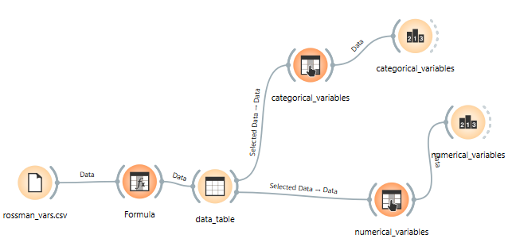

Orange3 Variable Ranking

Let’s break down what happens in each of our widgets. 1. Formula: In here we compute like_to_view_ratio and comment_view_ratio 2. Select Columns: We separate numerical features and categorical features 3. Rank: We rank features using RRelieF for categorical and Univar. reg. for numeric.

## Rank Widget Outputs

We recreate the rank widget table output

Categorical Features Ranked by RRelieF

| Feature | Rank | Score |
| --- | --- | --- |
| month | 1 | 0.482 |
| age_bin | 2 | 0.229 |
| category_id | 3 | 0.147 |
| weekday | 4 | 0.117 |
| duration_bucket | 5 | 0.094 |
| weekend | 6 | 0.001 |

Numeric Features Ranked by Univariate Regression

| Feature | Rank | Score |
| --- | --- | --- |
| age_days | 1 | 2279.794 |
| comment_view_ratio | 2 | 1799.709 |
| duration_seconds | 3 | 319.482 |
| comment_count | 4 | 79.074 |
| like_count | 5 | 50.098 |
| hour | 6 | 24.277 |
| view_count | 7 | 2.436 |

From the categorical variables, weekend was excluded due to its extremely low importance score and its conceptual overlap with weekday, which already captures temporal variation. Among the numerical variables, hour was removed given its low score and limited predictive contribution. In contrast, like_count, view_count, and comment_count were retained despite their relatively modest rankings, as they may offer incremental predictive value once combined with stronger features or transformed appropriately.

## Correlation Analysis and Model Comparison

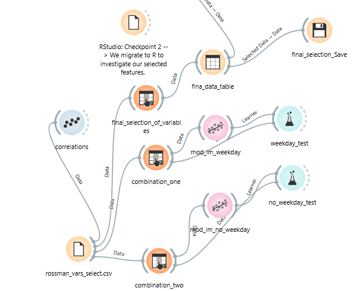

Orange3 Variable Selection

Pairwise Correlations Among Key Variables

| Pair | Correlation |
| --- | --- |
| view_count : like_count | 0.941 |
| comment_count : like_count | 0.982 |
| age_days : like_count | -0.161 |
| like_view_ratio : like_count | 0.122 |
| duration_seconds : like_count | -0.046 |
| comment_view_ratio : like_count | 0.036 |

Model Comparison: With vs. Without Weekday

| Model | RMSE | MAE | MAPE | R2 |
| --- | --- | --- | --- | --- |
| mod_lm_weekday | 0.017 | 0.013 | 30.231 | 0.594 |
| mod_lm_no_weekday | 0.017 | 0.013 | 29.994 | 0.596 |

**RStudio: Checkpoint 2**

# Importing the Orange-Selected Feature Set

We load the variables selected in Orange to continue the numerical and categorical analysis.

```r
selected_features <- read.csv("Data/rossman_vars_select_final.csv")
```

```
##   #               Name
##   1    like_view_ratio
##   2 comment_view_ratio
##   3              month
##   4           age_days
##   5        category_id
##   6            age_bin
##   7    duration_bucket
##   8   duration_seconds
##   9      comment_count
##  10         view_count
```

## Baseline Linear Model

Before applying any transformations, we fit a baseline linear model to establish a benchmark. This will let us evaluate whether subsequent feature changes improve performance and warrant adoption.

**Important: This R² is not for reporting; we use Orange results only. Included solely to gauge whether transformations improve the model.**

```r
initial.mod <- lm(formula = like_view_ratio ~ comment_view_ratio + month + age_days + category_id + age_bin + duration_bucket + duration_seconds + comment_count + view_count, data = selected_features)
```

```
## R² = 0.582
```

## Data Preparation: Numeric and Categorical

We separate features into numeric and categorical frames for clearer exploration.

```r
selected_features <- selected_features %>%
  dplyr::mutate(
    month = factor(month),
    category_id = factor(category_id),
    age_bin = factor(age_bin),
    duration_bucket = factor(duration_bucket)
  )

numerical_features <- selected_features %>%
  dplyr::select(
    like_view_ratio, comment_view_ratio,
    age_days, duration_seconds,
    comment_count, view_count
  )

categorical_features <- selected_features %>%
  dplyr::select(
    month, category_id,
    age_bin, duration_bucket
  )
```

```
## Total features: 10 -> like_view_ratio, comment_view_ratio, month, age_days, category_id, age_bin, duration_bucket, duration_seconds, comment_count, view_count
```

```
## Numeric features: 6 -> like_view_ratio, comment_view_ratio, age_days, duration_seconds, comment_count, view_count
```

```
## Categorical features: 4 -> month, category_id, age_bin, duration_bucket
```

## Numerical Variables

We inspect non-normality in our variables.

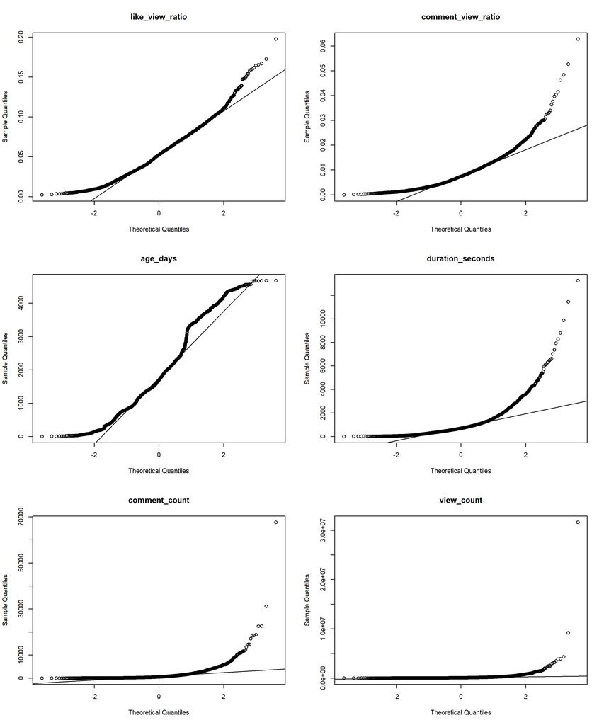

## Kurtosis diagnostics

To confirm the visual non-normality, we compute kurtosis for each variable. We target ≈ 3 and consider 2<x<4 acceptable. We then test log/Box–Cox transformations to bring outliers into this band.

```r
kurtosis_test_initial <- dplyr::reframe(numerical_features,
                 dplyr::across(where(is.numeric), ~ moments::kurtosis(., na.rm = T))) %>%
  tidyr::pivot_longer(everything(), names_to = "Variable", values_to = "Kurtosis") %>%
  dplyr::arrange(desc(Kurtosis))

print.data.frame(kurtosis_test_initial)
```

```
##             Variable    Kurtosis
## 1         view_count 1933.822703
## 2      comment_count  308.595361
## 3   duration_seconds   25.512560
## 4 comment_view_ratio   10.114542
## 5    like_view_ratio    3.730697
## 6           age_days    2.474440
```

## Log Transformations

Visual diagnostics and kurtosis statistics both indicate heavy tails. Several variables therefore require transformation. We test log transformations to see whether they reduce kurtosis toward the 2–4 range.

```r
log_transformations <- numerical_features %>%
    dplyr::mutate(
    log1p_like_view_ratio = log1p(like_view_ratio),
    log1p_comment_view_ratio = log1p(comment_view_ratio),
    log1p_duration_seconds = log1p(duration_seconds),
    log1p_view_count = log1p(view_count),
    log1p_comment_count = log1p(comment_count)
  ) %>%
  dplyr::select(
    -like_view_ratio,-comment_view_ratio,
    -duration_seconds, -view_count,
    -comment_count, -age_days
  )
```

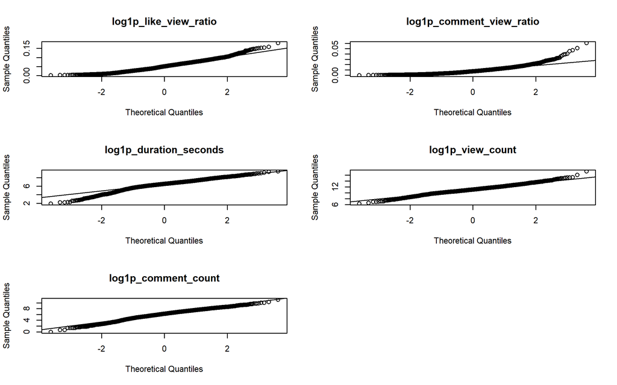

## Kurtosis test after Log Transformation

Re-evaluating kurtosis shows clear improvement. We now quantify the distance to normality (ideal ≈ 3; acceptable 2–4).

```r
kurtosis_test_log <- dplyr::reframe(
  log_transformations,
  dplyr::across(where(is.numeric), ~ moments::kurtosis(., na.rm = T)) %>%
    tidyr::pivot_longer(everything(), names_to = "Variable", values_to = "Kurtosis") %>%
    dplyr::arrange(desc(Kurtosis))
)

print.data.frame(kurtosis_test_log)
```

```
##                   Variable Kurtosis
## 1 log1p_comment_view_ratio 9.675110
## 2   log1p_duration_seconds 4.427117
## 3         log1p_view_count 3.843993
## 4    log1p_like_view_ratio 3.484667
## 5      log1p_comment_count 3.302994
```

## Box–Cox Likelihood

Suppose you have a regression model:

$$y_i = x_i^\top \beta + \varepsilon_i, \quad \varepsilon_i \sim N(0,
\sigma^2), \quad i = 1, \ldots, n$$

with strictly positive response values $y_i > 0$.

After applying the Box–Cox transformation:

$$y_i^{(\lambda)} =
\begin{cases}
\dfrac{y_i^\lambda - 1}{\lambda}, & \text{if } \lambda \neq 0, \\
\ln(y_i), & \text{if } \lambda = 0,
\end{cases}$$

the log-likelihood function for $\lambda$ (ignoring constants) is:

$$\ell(\lambda) = -\frac{n}{2} \ln \left( \frac{\text{RSS}(\lambda)}{n}
\right) + (\lambda - 1) \sum_{i=1}^n \ln y_i$$

**Note: We do not re-estimate λ in R; we reuse the λ values obtained in Orange.**

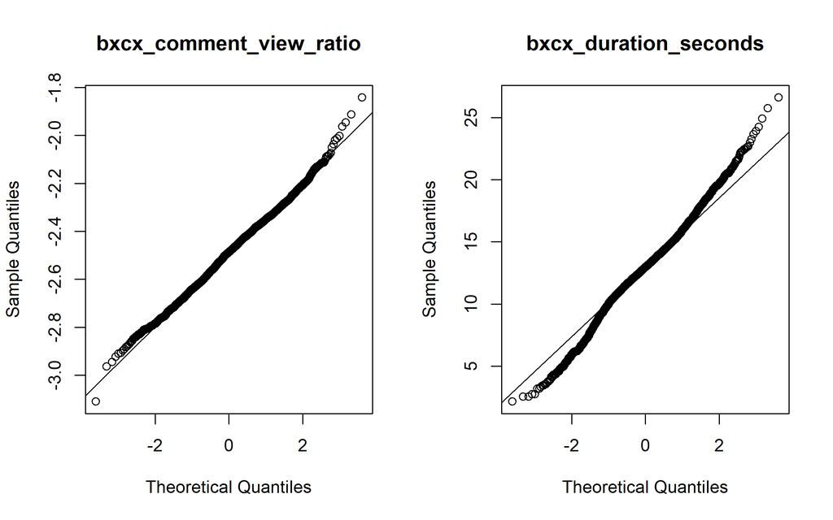

```r
# comment_view_ratio
# The first step is to nudge the variable by a minimal amount, say 1e-6 in order to fulfill the X > 0 rule in the Box-Cox formula.
comment_view_ratio_bxcx <- numerical_features$comment_view_ratio + 1e-6

# To find lambda, MASS::boxcox function needs a model fit to estimate the best transformation (λ value) for the dependent variable
# cvr_bxcx <- lm(comment_view_ratio ~ 1, data = (numerical_features*0.8))
# lambda.cvr <- cvr_bxcx$x[which.max(cvr_bxcx$y)]
lambda.cvr <- 0.3174754857788154 # We will use this value since we already computed λ for comment_view_ratio in Orange through a Python script. The value was computed on 0.8 of the data so there will be no data leakage on the test set.
# The steps here are described just to show the process for convenience. We should refer to the python_script inside Orange3 wf.

bxcx_comment_view_ratio <- if (lambda.cvr == 0) {
  log(comment_view_ratio_bxcx)
} else {
  (comment_view_ratio_bxcx^lambda.cvr - 1) / lambda.cvr
}

# duration_seconds
duration_seconds_bxcx <- numerical_features$duration_seconds

# We follow the same process
# ds_bxcx <- lm(duration_seconds ~ 1, data = (numerical_features * 0.8))
# lambda.ds <- ds_bxcx$x[which.max(ds_bxcx$y)]
lambda.ds <- 0.18964913615480788 # Already computed in Orange3 so we will use that value

bxcx_duration_seconds <- if (lambda.ds == 0) {
  log(duration_seconds_bxcx)
} else {
  (duration_seconds_bxcx^lambda.ds - 1) / lambda.ds
}

# Let's save the results in a df

bxcx_transformations <- data.frame(
  bxcx_comment_view_ratio = bxcx_comment_view_ratio,
  bxcx_duration_seconds = bxcx_duration_seconds
)

# Let's plot to see the results
```

## Kurtosis test after Box-Cox transformations

Visuals indicate improvement; we now quantify it with kurtosis. We target ≈ 3 and treat 2–4 as acceptable.

```r
kurtosis_test_boxcox <- dplyr::reframe(bxcx_transformations,
               dplyr::across(where(is.numeric), ~ moments::kurtosis(., na.rm = T))) %>%
  tidyr::pivot_longer(everything(), names_to = "Variable", values_to = "Kurtosis") %>%
  dplyr::arrange(desc(Kurtosis))

print.data.frame(kurtosis_test_boxcox)
```

```
##                  Variable Kurtosis
## 1   bxcx_duration_seconds 3.615032
## 2 bxcx_comment_view_ratio 3.119052
```

## Refit to Assess Improvement

We refit a comparable linear model using transformed features and compare adjusted R² to the baseline.

```r
numeric.mod <- lm(log_transformations$log1p_like_view_ratio ~ bxcx_transformations$bxcx_comment_view_ratio +
                    categorical_features$month + numerical_features$age_days +
                    selected_features$category_id + selected_features$age_bin + selected_features$duration_bucket +
                    bxcx_transformations$bxcx_duration_seconds + log_transformations$log1p_comment_count +
                    log_transformations$log1p_view_count
                    )
```

```
## R² = 0.641
```

## Final assessment of numeric transformations

We successfully normalized our variables to an acceptable degree (Kurtosis <4). The results are the following:

1. `view_count = log(view_count + 1)` — **Kurtosis = 3.84**
2. `like_view_ratio = log(like_view_ratio + 1)` — **Kurtosis = 3.48**
3. `comment_count = log(comment_count + 1)` — **Kurtosis = 3.30**
4. `comment_view_ratio = ((comment_view_ratio + 1e-6)^0.3174754857788154 - 1) / 0.3174754857788154` — **Kurtosis = 3.11**
5. `duration_seconds = ((duration_seconds + 0)^0.18964913615480788 - 1) / 0.18964913615480788` — **Kurtosis = 3.61**

These transformations bring distributions into the desired range and yielded a modest improvement in adjusted R².

We used R for QQ plots and kurtosis test from moments package to guide and verify transformations as these tools are not available in Orange3. With this roadmap, we will now replicate these transformations in Orange as required, and then proceed to analyze categorical variables.

## Categorical Variables

Let’s see the proportion of observations that are in each level of a category

```r
lapply(categorical_features, function(x) prop.table(table(x)))
```

```
## $month
## x
##        Apr        Aug        Dec        Feb        Jan        Jul        Jun
## 0.08838612 0.07843137 0.07631976 0.07119155 0.09170437 0.09019608 0.09291101
##        Mar        May        Nov        Oct        Sep
## 0.09472097 0.10015083 0.06455505 0.07631976 0.07511312
##
## $category_id
## x
##            2           15           19           20           22           23
## 0.0319758673 0.0096530920 0.0009049774 0.0030165913 0.1496229261 0.0012066365
##           24           25           27           28           29
## 0.0003016591 0.0877828054 0.6202111614 0.0576168929 0.0377073906
##
## $age_bin
## x
##         0-6d         1-2y         1-3m         1-4w         2-3y         3-6m
## 0.0006033183 0.0615384615 0.0111613876 0.0048265460 0.1318250377 0.0129713424
##          3y+        6-12m
## 0.7490196078 0.0280542986
##
## $duration_bucket
## x
##       <8m      >20m     8-20m
## 0.3263952 0.2365008 0.4371041
```

## Frequency analysis and level consolidation

Several levels of category_id and age_bin have negligible support. To improve statistical stability and interpretability, we consolidate sparse levels as follows:

category_id — Merge all levels with < 2% of observations (≈ 66 out of 3315) into “Other.”

age_bin — Combine the first two levels (0–6d and 1–4w) into ≤1m.

This reduces noise from rarely occurring categories and yields more reliable estimates in downstream modelling.

```r
# category_id

cutoff <- round(nrow(categorical_features)*0.02)

categorical_features <- categorical_features %>%
  dplyr::mutate(
    category_id = fct_lump_min(f = category_id, min = cutoff, other_level = "Other"),
    category_id = fct_drop(category_id),
    age_bin = fct_collapse(
      age_bin,
      `<=1m` = c("0-6d", "1-4w"),
      `1-3m` = "1-3m",
      `3-6m` = "3-6m",
      `6-12m` = "6-12m",
      `1-2y` = "1-2y",
      `2-3y` = "2-3y",
      `3y+` = "3y+"
    )
  )
```

```
##    Level Count     Feature  Proportion
## 1    3y+  2483     age_bin 0.749019608
## 2   2-3y   437     age_bin 0.131825038
## 3   1-2y   204     age_bin 0.061538462
## 4  6-12m    93     age_bin 0.028054299
## 5   3-6m    43     age_bin 0.012971342
## 6   1-3m    37     age_bin 0.011161388
## 7   <=1m    18     age_bin 0.005429864
## 8     27  2056 category_id 0.620211161
## 9     22   496 category_id 0.149622926
## 10    25   291 category_id 0.087782805
## 11    28   191 category_id 0.057616893
## 12    29   125 category_id 0.037707391
## 13     2   106 category_id 0.031975867
## 14 Other    50 category_id 0.015082956
```

## Refit to assess categorical consolidation

We refit the baseline linear model after merging sparse levels in category_id and age_bin and compare performance to the pre-consolidation benchmark.

```r
categorical.mod <- lm(selected_features$like_view_ratio ~ selected_features$comment_view_ratio + categorical_features$month +
                        selected_features$age_days + categorical_features$category_id +
                        categorical_features$age_bin + categorical_features$duration_bucket +
                        selected_features$duration_seconds + selected_features$comment_count +
                        selected_features$view_count
                        )
```

```
## R² = 0.605
```

## Variable optimization conclusion

Transforming both numerical and categorical variables improved model fit and the distributional quality of our features (kurtosis brought into the 2–4 band for key variables). We will keep these changes and replicate them in Orange.

Adjusted R² (internal benchmark):

Baseline (initial.mod): 0.582

After categorical consolidation (categorical.mod): 0.605 (Δ +0.023 vs baseline)

After numeric transformations (numeric.mod): 0.641 (Δ +0.059 vs baseline; +0.036 vs categorical)

Interpretation. The categorical merges reduce noise from sparsely populated levels, yielding a modest gain. The numerical transformations (log/Box–Cox) address heavy tails and stabilize variance, delivering the larger improvement in explanatory power.

**Note: These are adjusted R² values used for internal guidance; the report will use metrics computed in Orange.**

**Orange3: Checkpoint 2**

## We now move to Orange3 to apply the transformations.

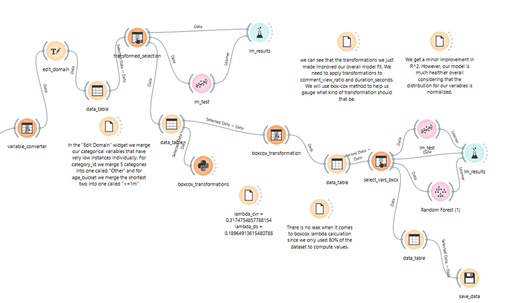

Orange3 Variable Transformation

Comparison of Model Performance after Log1p and Box-Cox Transformations

| Model | RMSE | MAE | MAPE | R2 |
| --- | --- | --- | --- | --- |
| Log1p Transformations | 0.015 | 0.011 | 26.832 | 0.630 |
| Log1p + Box-Cox Transformations | 0.015 | 0.011 | 26.381 | 0.635 |

## Final Modeling

The data was split using the 80/20 transformation. The following models were fit: XGBoost, Linear Regression, AdaBoost and Random Forest

[figure not shown]

Orange3 Final Model Fit

Performance of Final Models on Selected Variables

| Model | RMSE | MAE | MAPE | R2 |
| --- | --- | --- | --- | --- |
| XGBoost | 0.014 | 0.011 | 25.065 | 0.657 |
| Linear Regression | 0.015 | 0.011 | 26.622 | 0.636 |
| Random Forest | 0.014 | 0.010 | 23.510 | 0.700 |
| AdaBoost | 0.015 | 0.010 | 23.608 | 0.649 |

**RStudio: Checkpoint 3**

# Plots

We use R to produce higher-quality prediction plots, since Orange3’s plotting is limited. These figures supplement the plots generated in Orange.

## Load time series data

```r
timeseries_data <- read.csv(file = "Data/final_data_timeseries_test_orange_predictions.csv")

timeseries_data <- timeseries_data %>%
  mutate(
    published_at = as.POSIXct(x = published_at, format = "%m/%d/%Y",
                              tz = "UTC"),
    month = factor(month),
    age_bin = factor(age_bin),
    duration_bucket = factor(duration_bucket),
    category_id = factor(category_id)
  )

# Data table to parse model information for our plots

timeseries_data_mods <- timeseries_data %>%
  dplyr::select(published_at,
                actual = log1p_like_view_ratio,
                mod_lm, mod_xgboost, mod_rf, mod_adb
                ) %>%
  tidyr::pivot_longer(
    cols = starts_with("mod_"),
    names_to = "model",
    values_to = "pred"
  ) %>%
  dplyr::mutate(
    model = recode(
      model,
      "mod_lm" = "Linear Regression",
      "mod_rf" = "Random Forest",
      "mod_xgboost" = "XGBoost",
      "mod_adb" = "AdaBoost"
    ),
    model = factor(model, levels = c("Linear Regression", "Random Forest", "XGBoost", "AdaBoost")),
    resid = actual - pred
  )

# Let's add a smoothed table - the aim is to transform this into a non-stationary time series so we better capture structural changes.

timeseries_data_mods_smoothed <- timeseries_data_mods %>%
  group_by(model) %>%
  dplyr::arrange(published_at) %>%
  dplyr::mutate(
    actual_smooth = zoo::rollmean(actual, k = 7, fill = NA, align = "right"),
    pred_smooth = zoo::rollmean(pred, k = 7, fill = NA, align = "right")
  ) %>%
  ungroup()

# Let's create a custom color selection

color_selection <- c(
  "Actual" = "black",
  "Linear Regression" = "blue",
  "Random Forest" = "darkred",
  "XGBoost" = "steelblue",
  "AdaBoost" = "red"
  )
```

## Scatter plot of Predictive accuracy

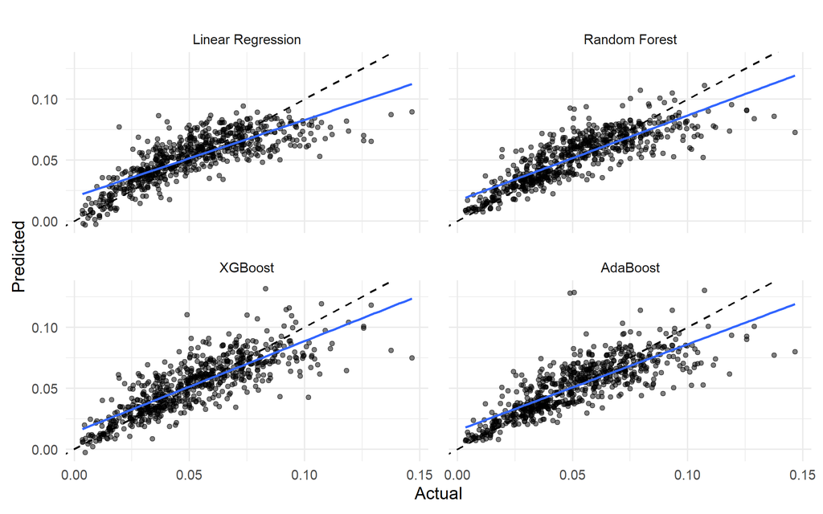

## Scatter plot of Residuals

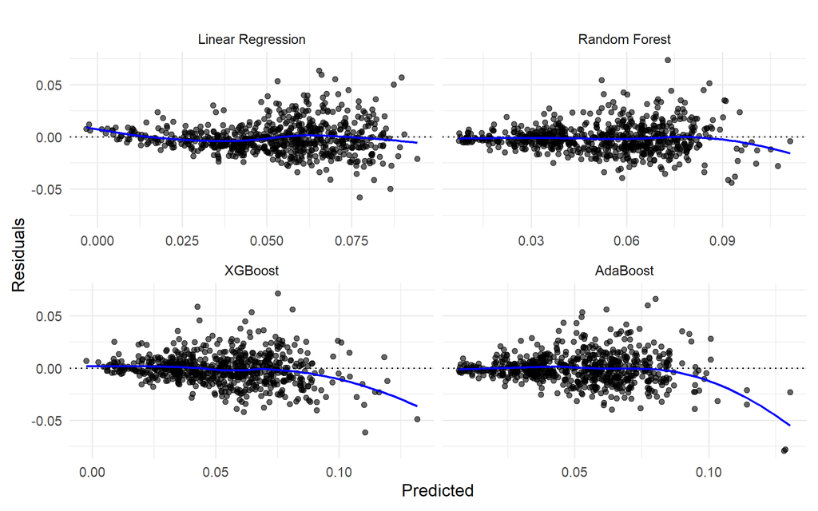

## Stationary Time-Series plot

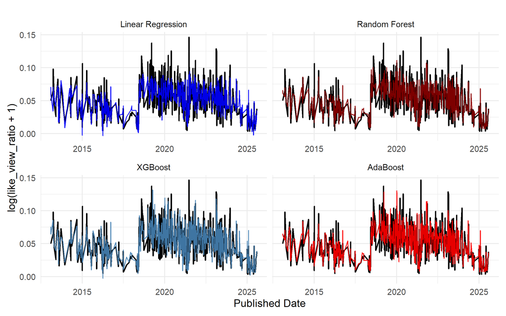

## Non-Stationary Time Series

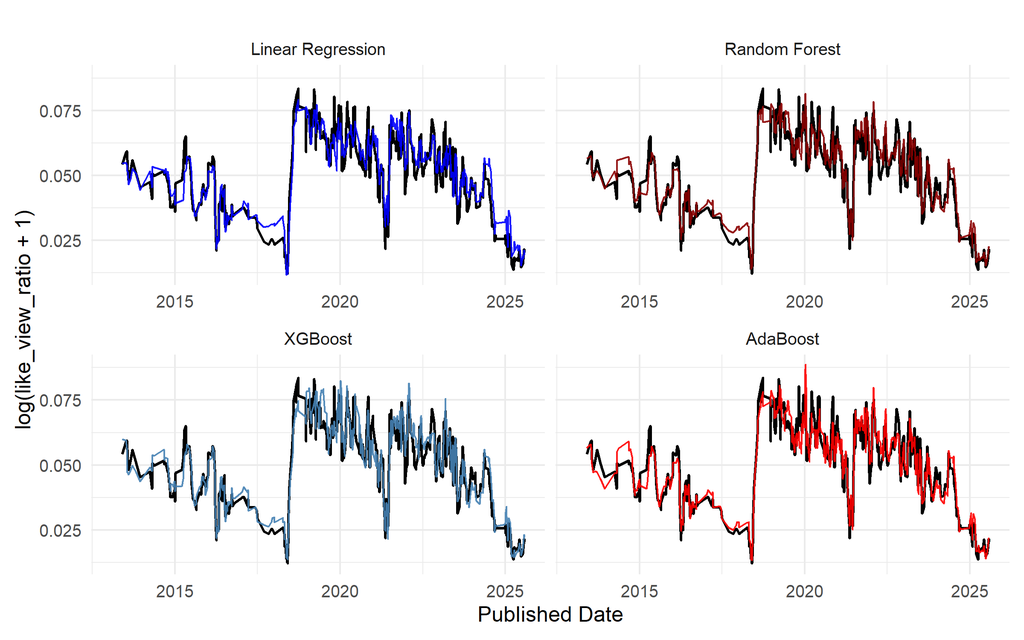